# Monitoramento Blend4

## Imports

## Diretório

## Base Blend4 em Produção

## Gráficos

# Uniproponente

# Primeira Semana

Acompanhamento diário do Mix de Modelos que estamos aplicando aos nossos leads.

```
Período: 2026-07-03 00:00:00 → 2026-07-10 00:00:00
Volume total: 25,915
```

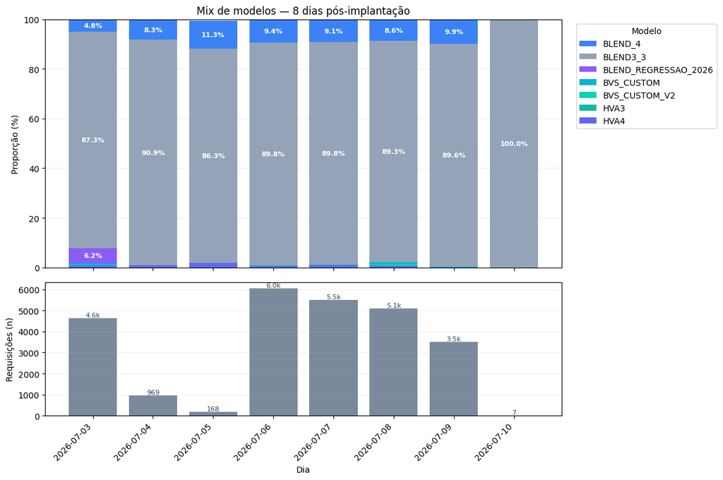

## Semanal

```
Semanas: 2 | Volume: 25,915
Período: 2026-07-03 00:00:00 → 2026-07-10 00:00:00
```

[figure not shown]

## Mix de Rating BLEND4 vs. BLEND3

Esse Mix de Rating não é exatamente o Mix de Rating visto na tabela do Funil, pois estamos avaliando o público que tem score Blend4, ou seja excluindo o público E-BVS.

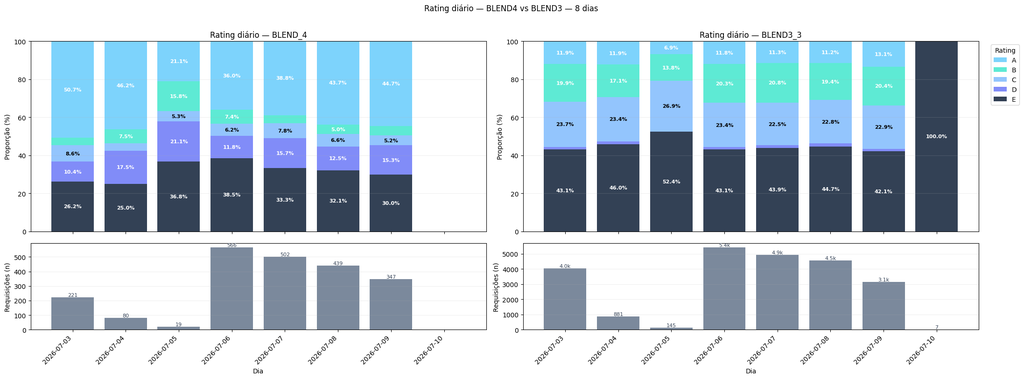

[figure not shown]

# Comparação: Score CR vs. Score Manual

Nessa secção queremos entender se não há nenhum erro de escoragem no Modelo BLEND4, ou seja, se score que está na CR é o mesmo que o escorado manualmente.

## Scores

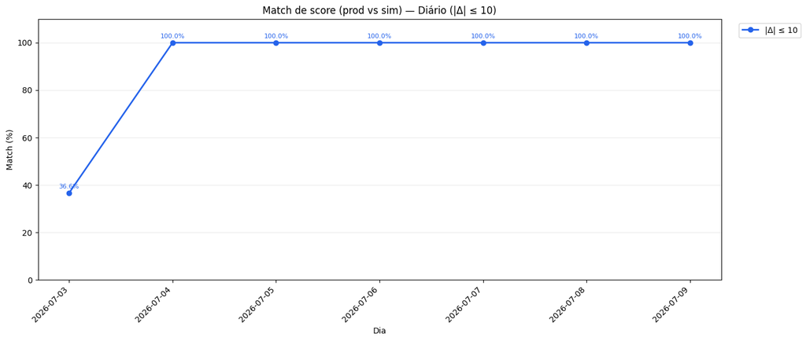

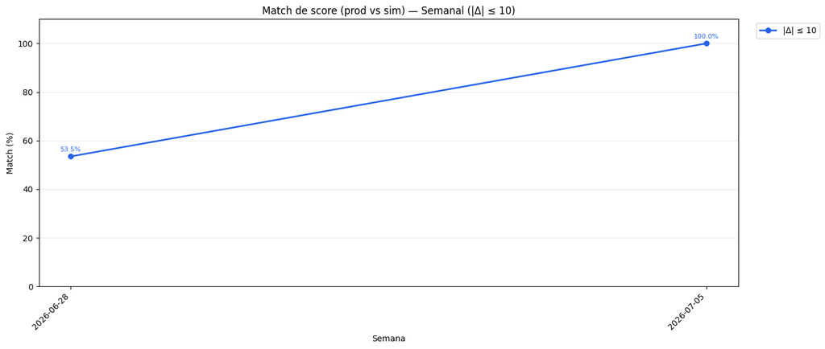

|  | period | volume_total | pct_match_abs_le_10 | score_abs_diff_mean |
| --- | --- | --- | --- | --- |
| 0 | 2026-07-03 | 221.0 | 36.65 | 19.0 |
| 1 | 2026-07-04 | 80.0 | 100.00 | 0.0 |
| 2 | 2026-07-05 | 19.0 | 100.00 | 0.0 |
| 3 | 2026-07-06 | 565.0 | 100.00 | 0.0 |
| 4 | 2026-07-07 | 501.0 | 100.00 | 0.0 |
| 5 | 2026-07-08 | 439.0 | 100.00 | 0.0 |
| 6 | 2026-07-09 | 347.0 | 100.00 | 0.0 |

## Ratings

No caos dos Ratings, o que queremos é entender se em dias que houve alguma falha de escoragem, se houve alteração no Mix.

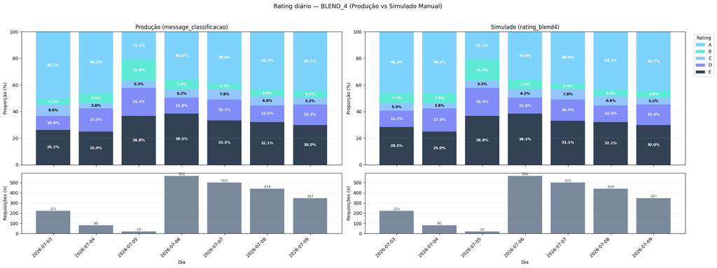

```
BLEND_4
```

| rating_manual_blend4 message_classificacao | A | B | C | D | E | All |
| --- | --- | --- | --- | --- | --- | --- |
| A | 888 | 11 | 0 | 0 | 0 | 899 |
| B | 1 | 118 | 2 | 0 | 0 | 121 |
| C | 0 | 0 | 135 | 9 | 0 | 144 |
| D | 0 | 0 | 0 | 289 | 6 | 295 |
| E | 0 | 0 | 0 | 3 | 712 | 715 |
| All | 889 | 129 | 137 | 301 | 718 | 2174 |

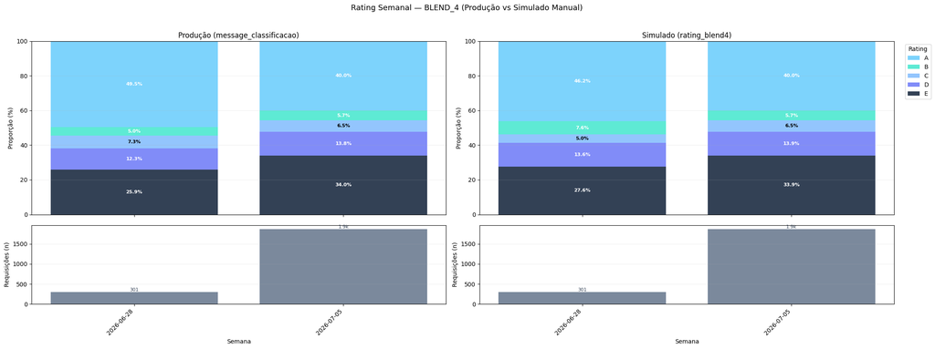

```
BLEND_4
```

| rating_manual_blend4 message_classificacao | A | B | C | D | E | All |
| --- | --- | --- | --- | --- | --- | --- |
| A | 888 | 11 | 0 | 0 | 0 | 899 |
| B | 1 | 118 | 2 | 0 | 0 | 121 |
| C | 0 | 0 | 135 | 9 | 0 | 144 |
| D | 0 | 0 | 0 | 289 | 6 | 295 |
| E | 0 | 0 | 0 | 3 | 712 | 715 |
| All | 889 | 129 | 137 | 301 | 718 | 2174 |

## PSI das Variáveis

```
Target day: 2026-07-09
```

|  | variable | comparison | psi | status | n_actual | psi_oot_vs_train_ref | psi_test_vs_train_ref |
| --- | --- | --- | --- | --- | --- | --- | --- |
| 0 | city_pc4_mais_100_contratos__pc_categorias | production_vs_train | 0.108431 | moderate | 347 | 0.054503 | 0.000085 |
| 1 | income_commitment | production_vs_train | 0.092933 | stable | 347 | 0.000865 | 0.000048 |
| 2 | SERASA_CHSV5 | production_vs_train | 0.070907 | stable | 347 | 0.020552 | 0.000130 |
| 3 | pred_blend4_1_to_score | production_vs_train | 0.046758 | stable | 347 | 0.023760 | 0.000040 |
| 4 | property_type | production_vs_train | 0.030836 | stable | 347 | 0.002975 | 0.000004 |
| 5 | score_proposto__bvs | production_vs_train | 0.030314 | stable | 347 | 0.010233 | 0.000116 |
| 6 | age | production_vs_train | 0.017867 | stable | 347 | 0.001148 | 0.000071 |
| 7 | qtde_restricoes__consulta_realizada | production_vs_train | 0.010045 | stable | 347 | 0.023589 | 0.000028 |
| 8 | city_pc4_mais_100_contratos__pc_categorias_is_... | production_vs_train | 0.006086 | stable | 347 | 0.000236 | 0.000011 |
| 9 | agency_pc4_mais_100_contratos__pc_categorias_i... | production_vs_train | 0.000726 | stable | 347 | 0.001303 | 0.000000 |
| 10 | flag_tem__contratos_anteriores | production_vs_train | 0.000625 | stable | 347 | 0.000000 | 0.000002 |
| 11 | agency_pc4_mais_100_contratos__pc_categorias | production_vs_train | 0.000164 | stable | 347 | 0.005090 | 0.000026 |
| 12 | flag_teve_boleto_atrasado__contratos_anteriores | production_vs_train | 0.000152 | stable | 347 | 0.000237 | 0.000002 |

```
['2026-06-28', '2026-07-05']
```

```
Target Week == 2026-07-05 (Semana Anterior Completa)
```

|  | variable | comparison | psi | status | n_actual | psi_oot_vs_train_ref | psi_test_vs_train_ref |
| --- | --- | --- | --- | --- | --- | --- | --- |
| 0 | city_pc4_mais_100_contratos__pc_categorias | production_vs_train | 0.079498 | stable | 1873 | 0.054503 | 0.000085 |
| 1 | SERASA_CHSV5 | production_vs_train | 0.069078 | stable | 1873 | 0.020552 | 0.000130 |
| 2 | income_commitment | production_vs_train | 0.059683 | stable | 1873 | 0.000865 | 0.000048 |
| 3 | pred_blend4_1_to_score | production_vs_train | 0.051799 | stable | 1873 | 0.023760 | 0.000040 |
| 4 | score_proposto__bvs | production_vs_train | 0.036028 | stable | 1873 | 0.010233 | 0.000116 |
| 5 | qtde_restricoes__consulta_realizada | production_vs_train | 0.020347 | stable | 1873 | 0.023589 | 0.000028 |
| 6 | city_pc4_mais_100_contratos__pc_categorias_is_... | production_vs_train | 0.010413 | stable | 1873 | 0.000236 | 0.000011 |
| 7 | age | production_vs_train | 0.009203 | stable | 1873 | 0.001148 | 0.000071 |
| 8 | property_type | production_vs_train | 0.005493 | stable | 1873 | 0.002975 | 0.000004 |
| 9 | agency_pc4_mais_100_contratos__pc_categorias | production_vs_train | 0.001207 | stable | 1873 | 0.005090 | 0.000026 |
| 10 | flag_teve_boleto_atrasado__contratos_anteriores | production_vs_train | 0.000065 | stable | 1873 | 0.000237 | 0.000002 |
| 11 | agency_pc4_mais_100_contratos__pc_categorias_i... | production_vs_train | 0.000021 | stable | 1873 | 0.001303 | 0.000000 |
| 12 | flag_tem__contratos_anteriores | production_vs_train | 0.000001 | stable | 1873 | 0.000000 | 0.000002 |

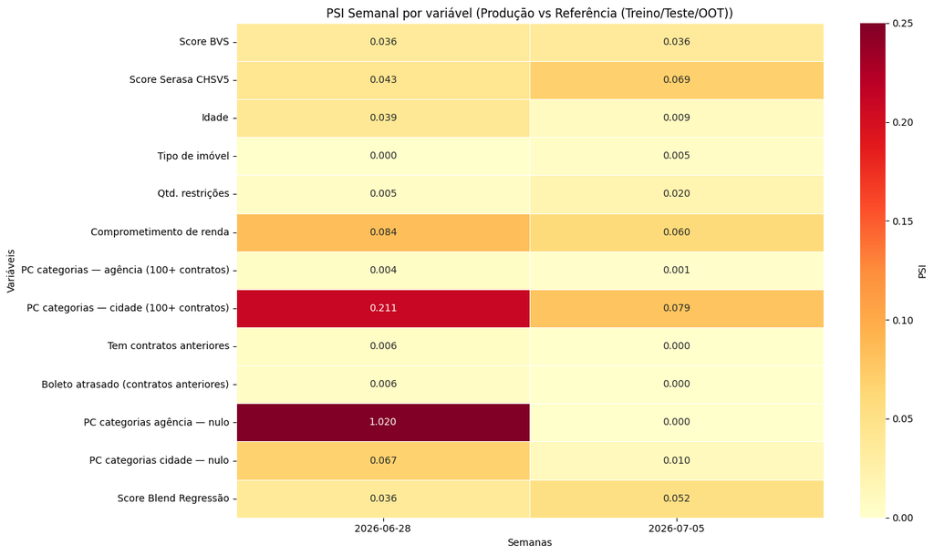

## PSI D-1

1. Adicionar % de cidades (conhecidas/) -- variável original
2. PC por quantil. Variável bruta

Ver Gráfico Esperado Funil e fazer algo aprecido

## PSI Semanal W-1 (Última Semana Completa)

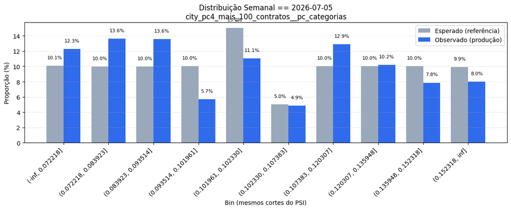

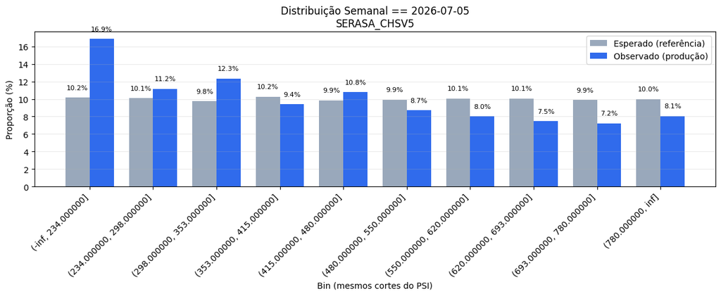

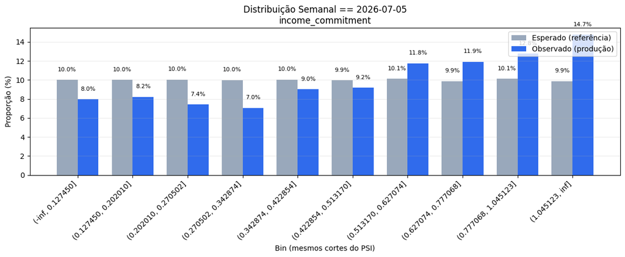

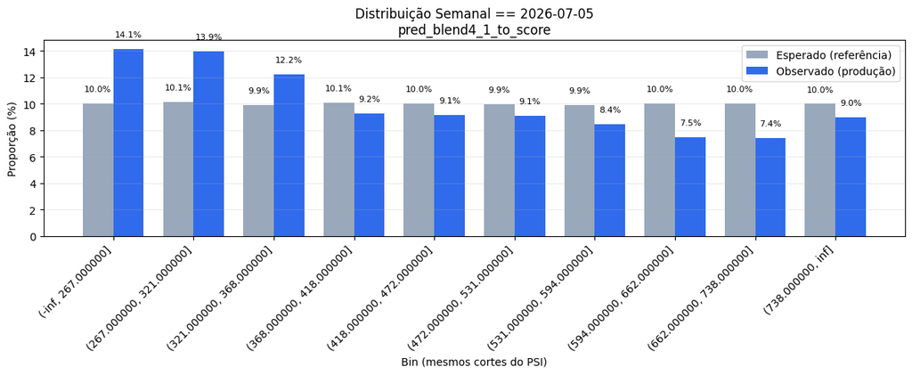

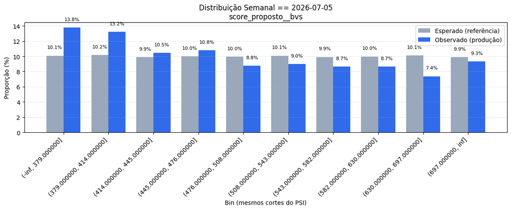

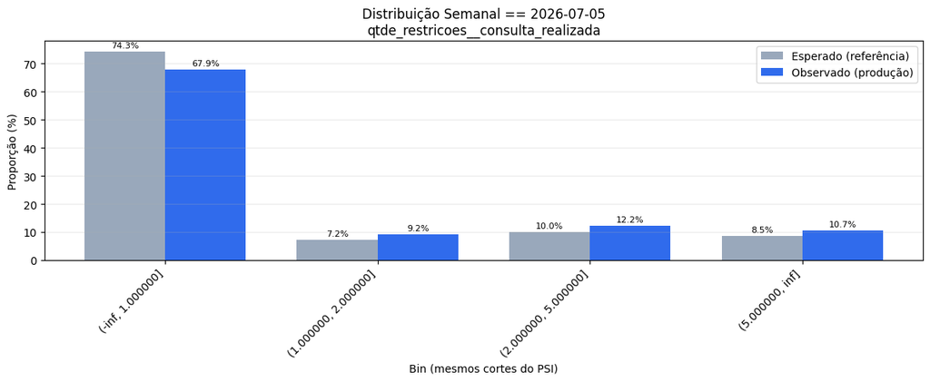

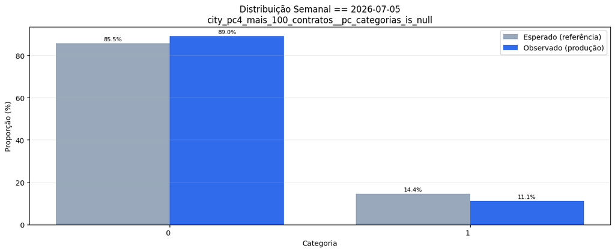

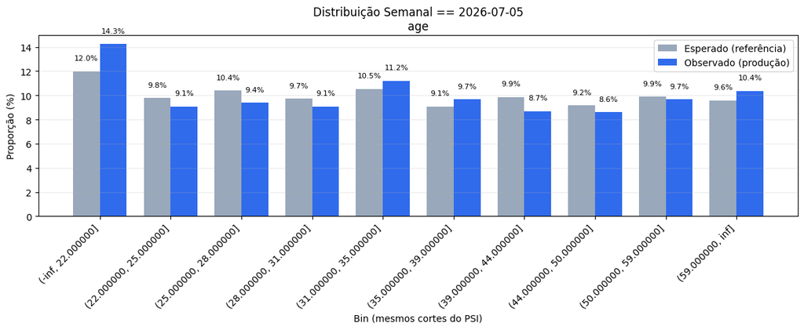

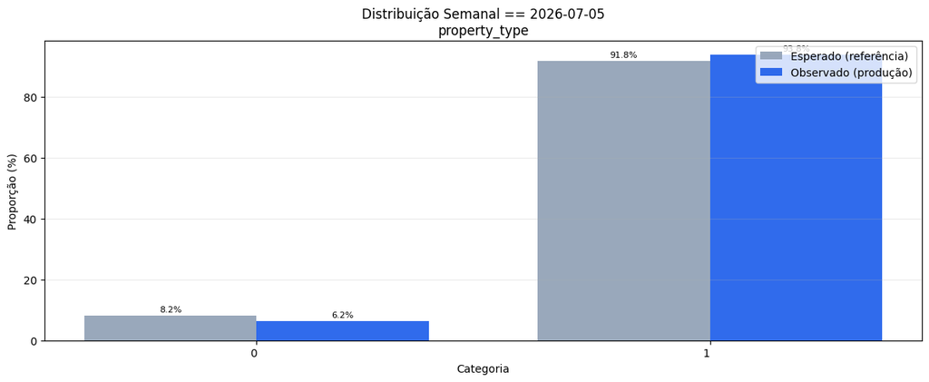

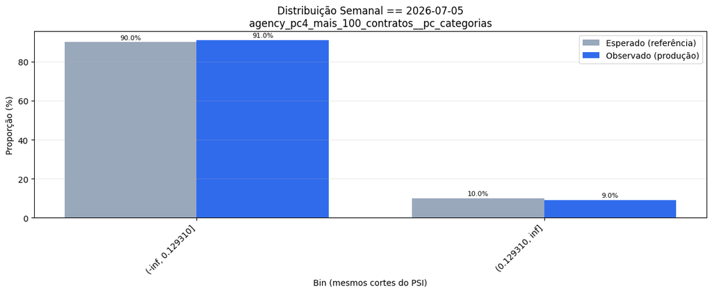

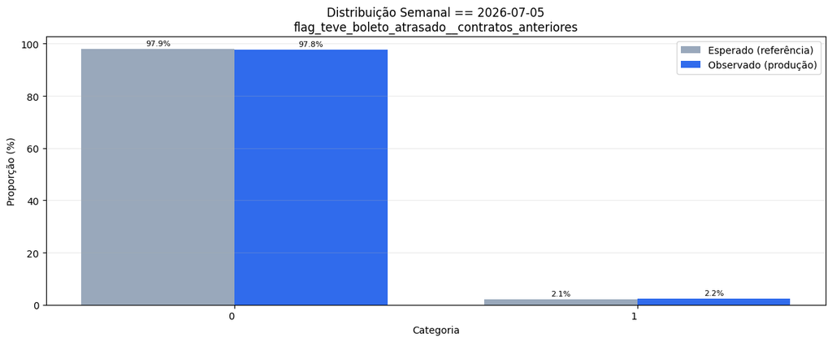

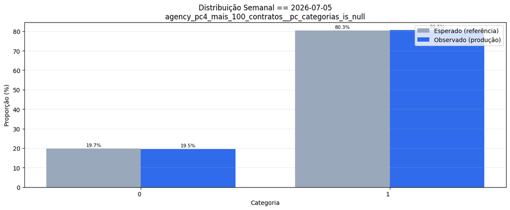

# Falhas - Uniproponente

Garantir que não estamos comprando SERASA para esse público

10-11% do público OOT passa direto por BVS (Blend4). 15-17% é Rating E pelo Score BVS.

[figure not shown]

[figure not shown]

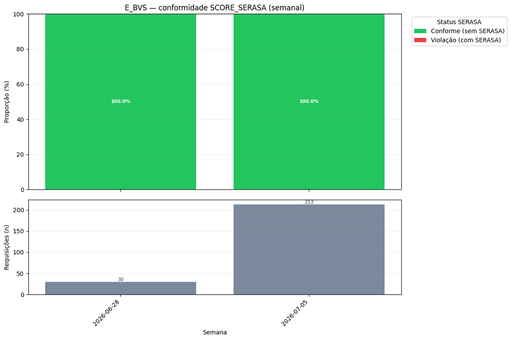

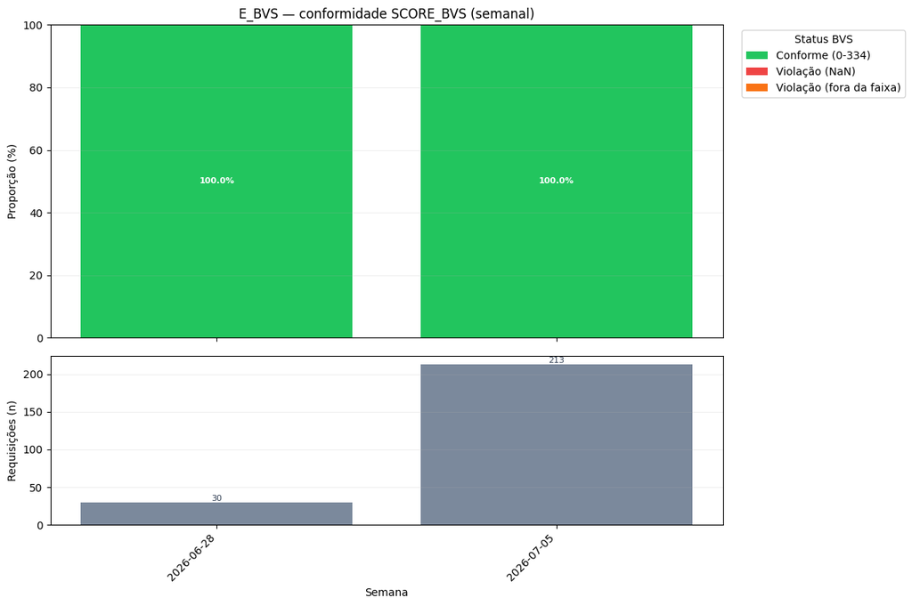

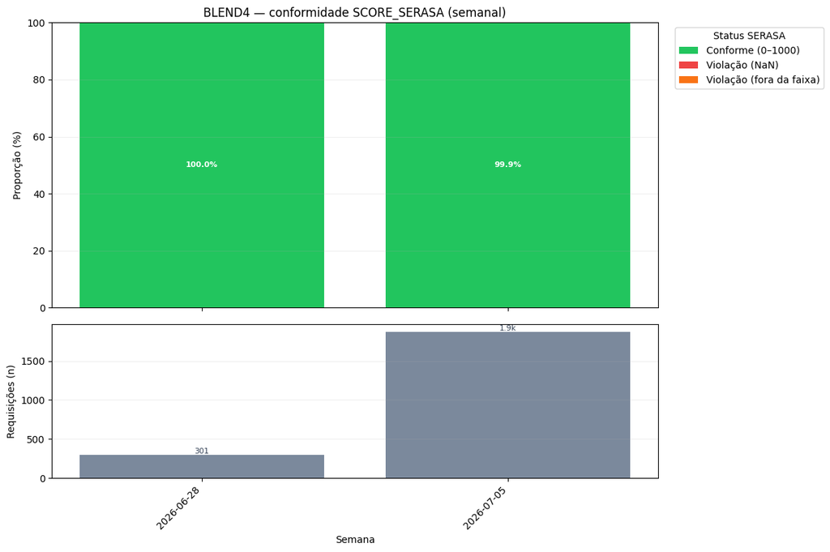

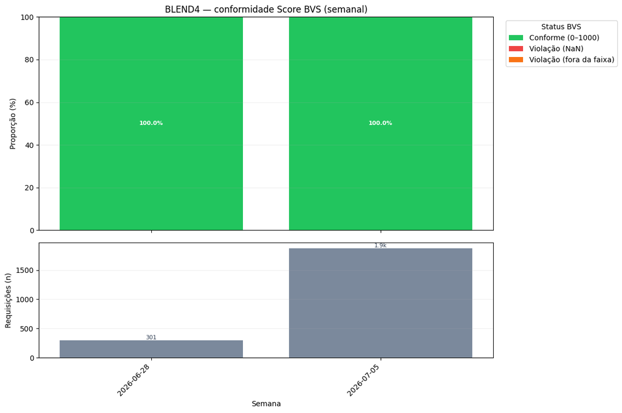

# PSI Base Geral Uniproponente

## Dia e Semana Raw

```
Período: 2026-07-03 00:00:00 → 2026-07-10 00:00:00
Volume total: 26,158
```

```
Semanas: 2 | Volume: 26,158
Período: 2026-07-03 00:00:00 → 2026-07-10 00:00:00
```

```
Target day: 2026-07-09
```

```
Target Week == 2026-06-28 (Última Semana Completa)
```

## PSI RAW BVS

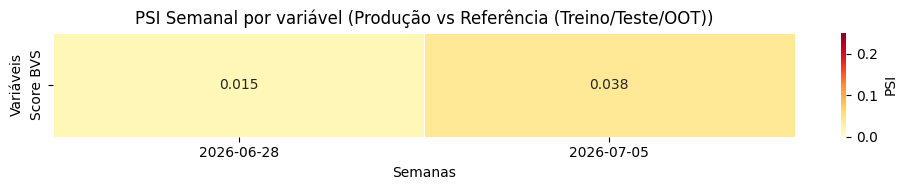

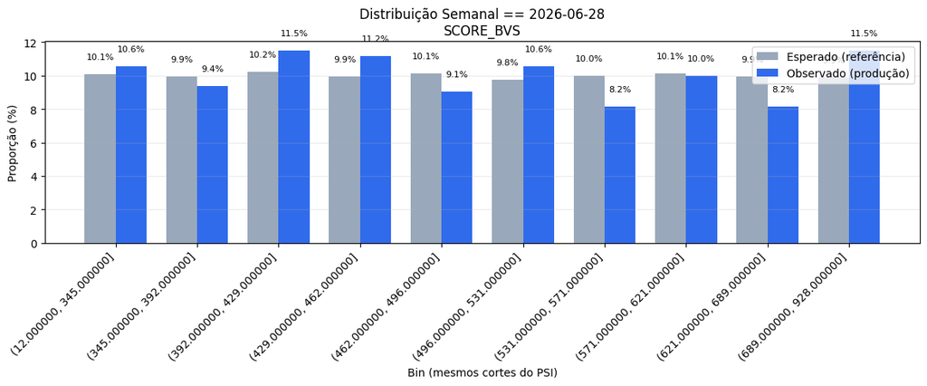

## PSI RAW Renda e Aluguel

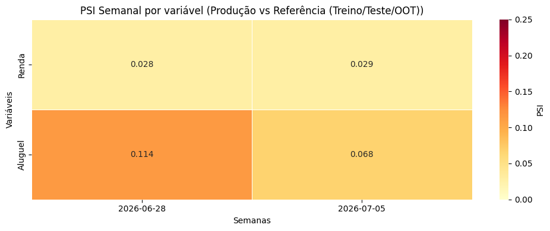

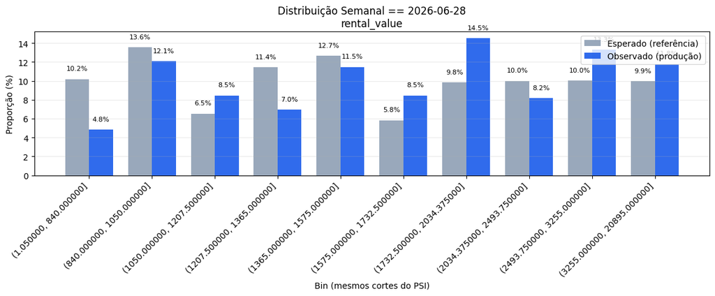

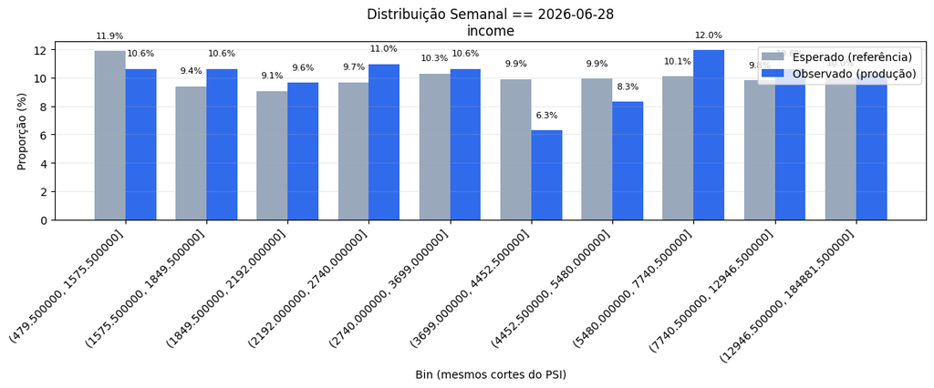